# Afstande udfra data

A-niveau

Det er ikke altid helt klart, hvordan man skal bestemme afstanden mellem to datapunkter, hvis koordinaterne i hvert datapunkter beskriver vidt forskellige ting. Vi vil her se nærmere på, hvilke problemer, der kan opstå, hvis man ikke tænker sig om – og hvad man kan gøre for at løse dem.

## Afstand med hovedet under armen

Lad os forestille os, at data består af vægt og højde for nogle personer, så hvert datapunkt er på formen
$$(v,h)$$
hvor $v$ er den pågældende persons vægt og $h$ er højden. Her er det faktisk ikke klart, hvad afstanden mellem to punkter $(v_1,h_1)$ og $(v_2,h_2)$ skal være. Altså, hvornår to punkter ligger tæt på hinanden.

Et første bud kunne være at bestemme den euklidske afstand mellem de to punkter – det der bare svarer til at bruge Pythagoras. Gør vi det får vi følgende afstandsmål mellem punkterne $(v_1,h_1)$ og $(v_2,h_2)$

$$\sqrt{(v_2-v_1)^2+(h_2-h_1)^2}$$

Vi prøver at regne lidt på det, og forestille os at tre personer er givet som datapunkter i nedenstående tabel.

| Person | (vægt, højde) |
| --- | --- |
| A | $(70 \ kg, 165 \ cm)$ |
| B | $(90 \ kg, 180 \ cm)$ |
| C | $(80 \ kg, 190 \ cm)$ |

Bruger vi Pythagoras på tallene, der står her, er:

$$\begin{align*}
&\text{Afstanden mellem A og B: } \sqrt{20^2+15^2}=25 \\
&\text{Afstanden mellem A og C: } \sqrt{10^2+25^2}\simeq 27 \\
&\text{Afstanden mellem B og C: } \sqrt{10^2+10^2}\simeq 14
\end{align*}$$

Med dette afstandsmål er der altså længst fra $A$ til $C$.

Skifter vi nu enhed og udtrykker højden i meter får vi følgende datapunkter:

| Person | (vægt, højde) |
| --- | --- |
| A | $(70 \ kg, 1.65 \ m)$ |
| B | $(90 \ kg, 1.80 \ m)$ |
| C | $(80 \ kg, 1.90 \ m)$ |

Nu er

$$\begin{align*}
&\text{Afstanden mellem A og B: } \sqrt{20^2+0.15^2} \simeq 20 \\
&\text{Afstanden mellem A og C: } \sqrt{10^2+0.25^2} \simeq 10 \\
&\text{Afstanden mellem B og C: } \sqrt{10^2+0.10^2} \simeq 10
\end{align*}$$

Der er nu længst fra $A$ til $B$.

Det er ikke ret smart. Skal man finde de datapunkter, som ligger tættest på hinanden, er svaret tilsyneladende som vinden blæser og afhængig af hvilken enhed, vi har valgt at måle i.

Men selv hvis begge variable er i samme enhed, kan Pythagoras brugt med hovedet under armen være uheldigt, som nedenstående eksempel illustrerer.

Vi forestiller os, at vi har data for, hvor meget familierne $A$, $B$ og $C$ bruger på bolig og på mælk om måneden. Begge variable kan være i kroner. I tabellen ses et eksempel:

| Familie | (bolig, mælk) |
| --- | --- |
| A | $(7500 \ kr, 200 \ kr)$ |
| B | $(7500 \ kr, 1700 \ kr)$ |
| C | $(6000 \ kr, 200 \ kr)$ |

Det vil altså for eksempel sige, at familie $A$ bruger $7500$ kr på bolig og $200$ kr på mælk. Her er afstanden udregnet med Pythagoras:

$$\begin{align*}
&\text{Afstanden mellem A og B: } \sqrt{0^2+1500^2} = 1500 \\
&\text{Afstanden mellem A og C: } \sqrt{1500^2+0^2} = 1500 \\
&\text{Afstanden mellem B og C: } \sqrt{1500^2+1500^2} \simeq 2121
\end{align*}$$

Altså er der samme afstand fra $A$ til $B$ som fra $A$ til $C$, men vi vil nok mene, at $B$ afviger mere fra $A$ end $C$ gør, fordi mælkeforbruget i familie $B$ er usædvanligt.

Har vi data for mange familier, kan vi kvantificere idéen om, hvad der er usædvanligt og bruge det til at lave en mere passende afstand.

## Første naive tilgang: Min-Max-skalering

Eksemplet ovenfor illustrerer, at det nok vil være smart at prøve at inddrage i hvilket interval $x$- og $y$-værdierne varierer. For eksempel er et udsving på $500$ kr i boligudgifter ikke lige så voldsomt, som et udsving på $500$ kr i mælkeudgifter. Problemet er, at den *absolutte* forskel på henholdsvis $x$- og $y$-værdierne ikke er sammenlignelige her.

Lad os sige, at vi betrager datapunkter $(x_i,y_i)$ i planen, hvor $x$-værdierne ligger mellem $a$ og $b$, mens $y$-værdierne ligger mellem $c$ og $d$. Situationen er illustreret i figur 1.

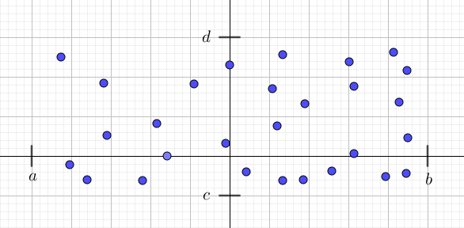

Figur 1: Datapunkter i planen, hvor $x$-værdierne ligger mellem $a$ og $b$, mens $y$-værdierne ligger mellem $c$ og $d$.

Idéen er nu, at vi skalerer, så afstandene langs $x$-aksen får samme vægt som afstandene langs $y$-aksen.

Det vil sige, at vi definerer afstanden fra $(x_1,y_1)$ til $(x_2,y_2)$ som

$$\sqrt{\left ( \frac{x_2-x_1}{b-a} \right )^2+ \left ( \frac{y_2-y_1}{d-c} \right )^2} \tag{1}$$

Det får den betydning, at hvis $x$-værdierne f.eks. kan varierer i et langt bredere interval end $y$-værdierne (dvs. at $b-a>d-c$), så bliver forskellen på $x$-værdierne i ovenstående afstandsmål skaleret mere ned (fordi vi kommer til at dividere med et større tal). En anden måde at forstå dette afstandsmål på, er ved at erstatte hvert punkt $(x_i,y_i)$ med et nyt skaleret punkt:

$$(x_i,y_i)_{Norm}=\left(\frac{x_i-a}{b-a}, \frac{y_i-c}{d-c}\right) \tag{2}$$

Resultatet af at lave denne skalering af punkterne fra figur 1 ses i figur 2.

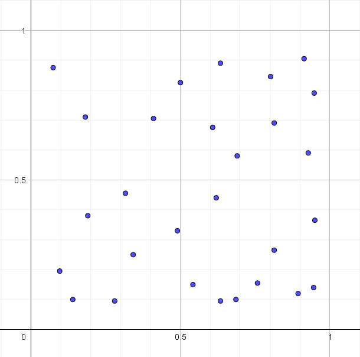

Figur 2: Datapunkterne fra figur 1, men hvor alle punkter er blevet skaleret ved at bruge formlen i (2).

Bemærk, at datapunkterne nu er skaleret på en sådan måde, at alle $x$- og $y$-værdier ligger mellem $0$ og $1$. Derfor giver det mening, at bruge Pythagoras på disse skalerede punkter – og gør vi det, får vi

$$\sqrt{\left(\frac{x_2-a}{b-a}-\frac{x_1-a}{b-a}\right)^2 +\left(\frac{y_2-c}{d-c}-\frac{y_1-c}{d-c}\right)^2}=\sqrt{\left(\frac{x_2-x_1}{b-a}\right)^2+\left(\frac{y_2-y_1}{d-c}\right)^2}$$

Bemærk, at det præcis er afstandsmålet i (1).

## Mindre naivt, mere bøvlet: Feature scaling

Den skalering vi har præsenteret i (2) benytter ikke som sådan information om data, men kun om den mindste og største værdi, som henholdsvis $x$- og $y$-værdier ligger imellem (nemlig $a$ og $b$ for $x$-værdierne og $c$ og $d$ for $y$-værdierne).

Et alternativ til dette er at bruge data til at bestemme skaleringen. Dette kaldes for *feature scaling*, når vi arbejder med perceptroner eller neurale netværk. Hvis de data, der skal læres fra – det vil sige træningsdata – er
$$(x_1,y_1), (x_2,y_2),\ldots, (x_n,y_n)$$
så skalerer vi langs førsteaksen ved, at

- udregne et estimat for middelværdien af $x$:
  $$\bar{x}=\frac{x_1 + x_2 + \cdots + x_n}{n}=\frac{\Sigma_{i=1}^nx_i}{n}$$
- og et estimat for denne variabels spredning:
  $$s_x=\sqrt{\frac{\Sigma_{i=1}^n(x_i-\bar{x})^2}{n-1}}$$

Feature scaling af $x_i$ er da
$$\hat{x}_i=\frac{x_i-\bar{x}}{s_x} \tag{3}$$

Tilsvarende estimeres middelværdi og spredning for $y$ og feature scaling udregnes:
$$\hat{y}_i= \frac{y_i-\bar{y}}{s_y} \tag{4}$$

Resultatet af at lave denne feature skalering af punkterne fra figur 1 ses i figur 3.

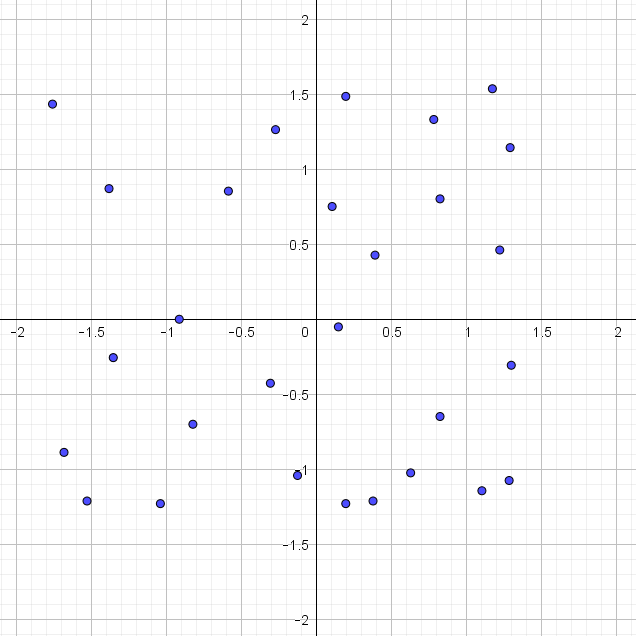

Figur 3: Datapunkterne fra figur 1, men hvor alle punkter er blevet feature skaleret ved at bruge formlerne i (3) og (4).

Bemærk, hvordan de feature skalerede datapunkter har $x$- og $y$-værdier, som alle[^1] ligger mellem $-2$ og $2$.

<sup>1</sup> I virkelighedens verden kan der godt være værdier, som er mindre end $-2$ eller større end $2$, men som oftest vil det være sådan, at omkring $95 \%$ af værdierne vil ligge mellem $-2$ og $2$ efter feature skalering.

Da alle $x$- og $y$-værdier nu er på samme skala, giver det igen mening at beregne den euklidiske afstand mellem disse nye punkter. Betragter vi de skalerede punkter $(\hat{x}_1,\hat{y}_1)$ og $(\hat{x}_2,\hat{y}_2)$ så bliver den euklidiske afstand mellem dem

$$\begin{align*}
\sqrt{(\hat{x}_2-\hat{x}_1)^2+(\hat{y}_2-\hat{y}_1)^2} &= \sqrt{\left(\frac{x_2-\bar{x}}{s_x}-\frac{x_1-\bar{x}}{s_x}\right)^2 +\left(\frac{y_2-\bar{y}}{s_y}-\frac{y_1-\bar{y}}{s_y}\right)^2}\\
& =\sqrt{\left(\frac{x_2-x_1}{s_x}\right)^2+\left(\frac{y_2-y_1}{s_y}\right)^2}
\end{align*}$$

Hvis vi sammenligner med den naive tilgang i (1), er den ikke helt skæv. Der skal bare skaleres med $s_x$ i stedet for $b-a$ og med $s_y$ i stedet for $c-d$.

Bemærk, at den feature skalering, som foretages i (3) og (4), svarer til at standardisere en normalfordelt stokastisk variabel $X \sim N(\mu, \sigma)$:

$$Z = \frac{X-\mu}{\sigma}$$
Derfor vil det også være sådan, at hvis de oprindelige data er normalfordelte, så vil de nye feature skalerede data være standard normalfordelte (dvs. normalfordelte med middelværdi $0$ og spredning $1$). Heraf følger også, at cirka $95 \%$ af de feature skalerede data vil ligge mellem $-2$ og $2$.

## Eksempel: Feature scaling

Vi vil prøve at se på et udvidet eksempel om udgifter til bolig og mælk. Se nedenstående tabel:

| Familie | (bolig, mælk) |
| --- | --- |
| A | $(7500 \ kr, 200 \ kr)$ |
| B | $(7500 \ kr, 1700 \ kr)$ |
| C | $(6000 \ kr, 200 \ kr)$ |
| D | $(5200 \ kr, 300 \ kr)$ |
| E | $(8100 \ kr, 250 \ kr)$ |
| F | $(6200 \ kr, 350 \ kr)$ |
| G | $(7700 \ kr, 400 \ kr)$ |
| H | $(5800 \ kr, 350 \ kr)$ |
| I | $(7200 \ kr, 250 \ kr)$ |
| J | $(6800 \ kr, 400 \ kr)$ |

Datapunkterne fra tabellen ses indtegnet i figur 4. De tre første familier $A$, $B$ og $C$ fra det tidligere eksempel er markeret. Bemærk, at vi tidligere har beregnet, at afstanden mellem $A$ og $B$ er den samme som afstanden mellem $A$ og $C$. Det ser måske ikke umiddelbart sådan ud i figur 4, men det skyldes, at enheden på de to akser er forskellige.

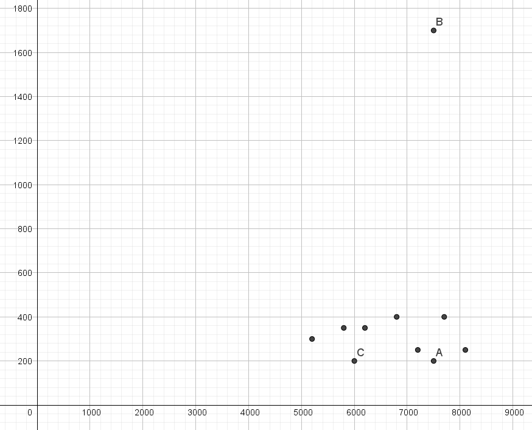

Figur 4: Datapunkterne fra eksemplet omkring udgifter til bolig og mælk.